# Initial NARTs analysis

NARTS are a DfE (and previously BIS) thing.

They are National Achievement Rates Tables for the FE system, and come as zipped bundles of csv files. There is a separate GDS page for each year (grrr) which are (2017) linked from https://www.gov.uk/government/collections/sfa-national-success-rates-tables.

As there are numerous zipped bundles on each of the annual pages, the sensible thing is to use the Firefox extension ‘Downthemall’ to download all the bundles on a page, and work from there. Doing that gives us (to 2015-6 completed) 340Mb of files including zipfiles.

The initial target is to reproduce a helpful chart tweeted by Ben Verinder at https://twitter.com/BenVerinder/status/915206826165260290.

This shows 19+ participation in Education and Training by the level of education, over the three years to 2015-16.

First of all, replicating Ben Verinder’s chart requires getting the data from separate csv files for each year. These files have highly variable names - and I’ve extracted the zip bundles into directories, using 7-zip so I could do multiple ones in sequence, so the zip bundle names are there too. There’s no easy way to do this.

```r
library(tidyverse)
```

The 2014-5 dataset includes data for 2013-4, so I’ve included the 2013-4 data as a check - these have slightly different definitions.However, the 2014-5 dataset also brings in the participant volumes as a character field, with commas for the thousands. This needs correcting.

This code filters the data, selects the minimum number of fields, and then guesses to convert the numbers actually into numbers. It does convert qualification levels into numbers too. At the end, our 2015-6 and 2014-5 files are identically structured, so I can bind them together.

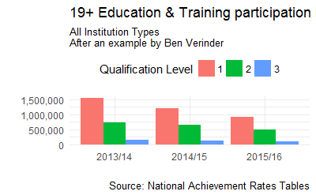

```r
et2015_6 %>% filter(`Institution Type` == "All Institution Type", Age == "19+", `Qualification Level` %in% c(1,2,3)) %>%  select(`Hybrid End Year`, `Qualification Level`, `Overall Cohort`) %>% type_convert()-> et2015_6_short
et2014_5 %>% filter(`Institution Type` == "All Institution Type", Age == "19+", `Qualification Level` %in% c(1,2,3)) %>%  select(`Hybrid End Year`, `Qualification Level`, `Overall Cohort`) %>% type_convert()-> et2014_5_short
et2013_4 %>% filter(Institution_Type == "All Institution Type", Age == "19+", Qualification_Level %in% c(1,2,3)) %>%  select(Hybrid_End_Year, Qualification_Level, `Overall_Leavers`) %>% type_convert() -> et2013_4_short
et2013_6_short <- bind_rows(et2014_5_short, et2015_6_short)
ggplot(et2013_6_short, aes(x=`Hybrid End Year`, y=`Overall Cohort`, fill=as.factor(`Qualification Level`))) + geom_bar(position="dodge", stat="identity") + scale_y_continuous(labels=scales::comma_format()) + theme_minimal() + labs(x="", y="", title="19+ Education & Training participation by level 2013-2016", subtitle="All Institution Types \nAfter an example by Ben Verinder", caption = "Source: National Achievement Rates Tables") + guides(fill=guide_legend(direction="horizontal", title="Qualification Level")) + theme(legend.position="top")
```

Following Verinder’s hint, repeating the same code for each type of institution gives the following:

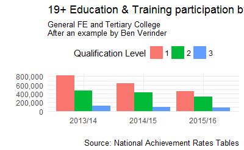

```r
et2015_6 %>% filter(`Institution Type` == "General FE and Tertiary College", Age == "19+", `Qualification Level` %in% c(1,2,3)) %>%  select(`Hybrid End Year`, `Qualification Level`, `Overall Cohort`) %>% type_convert()-> et2015_6_short
et2014_5 %>% filter(`Institution Type` == "General FE and Tertiary College", Age == "19+", `Qualification Level` %in% c(1,2,3)) %>%  select(`Hybrid End Year`, `Qualification Level`, `Overall Cohort`) %>% type_convert()-> et2014_5_short
et2013_4 %>% filter(Institution_Type == "General FE and Tertiary College", Age == "19+", Qualification_Level %in% c(1,2,3)) %>%  select(Hybrid_End_Year, Qualification_Level, `Overall_Leavers`) %>% type_convert() -> et2013_4_short
et2013_6_short <- bind_rows(et2014_5_short, et2015_6_short)
ggplot(et2013_6_short, aes(x=`Hybrid End Year`, y=`Overall Cohort`, fill=as.factor(`Qualification Level`))) + geom_bar(position="dodge", stat="identity") + scale_y_continuous(labels=scales::comma_format()) + theme_minimal() + labs(x="", y="", title="19+ Education & Training participation by level 2013-2016", subtitle="General FE and Tertiary College \nAfter an example by Ben Verinder", caption = "Source: National Achievement Rates Tables") + guides(fill=guide_legend(direction="horizontal", title="Qualification Level")) + theme(legend.position="top")
```

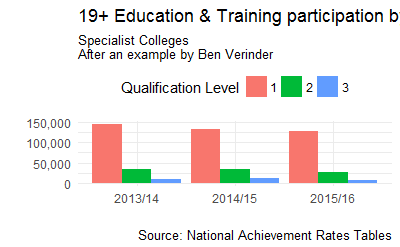

```r
et2015_6 %>% filter(`Institution Type` == "Specialist College", Age == "19+", `Qualification Level` %in% c(1,2,3)) %>%  select(`Hybrid End Year`, `Qualification Level`, `Overall Cohort`) %>% type_convert()-> et2015_6_short
et2014_5 %>% filter(`Institution Type` == "Specialist College", Age == "19+", `Qualification Level` %in% c(1,2,3)) %>%  select(`Hybrid End Year`, `Qualification Level`, `Overall Cohort`) %>% type_convert()-> et2014_5_short
et2013_4 %>% filter(Institution_Type == "Specialist College", Age == "19+", Qualification_Level %in% c(1,2,3)) %>%  select(Hybrid_End_Year, Qualification_Level, `Overall_Leavers`) %>% type_convert() -> et2013_4_short
et2013_6_short <- bind_rows(et2014_5_short, et2015_6_short)
ggplot(et2013_6_short, aes(x=`Hybrid End Year`, y=`Overall Cohort`, fill=as.factor(`Qualification Level`))) + geom_bar(position="dodge", stat="identity") + scale_y_continuous(labels=scales::comma_format()) + theme_minimal() + labs(x="", y="", title="19+ Education & Training participation by level 2013-2016", subtitle="Specialist Colleges \nAfter an example by Ben Verinder", caption = "Source: National Achievement Rates Tables") + guides(fill=guide_legend(direction="horizontal", title="Qualification Level")) + theme(legend.position="top")
```

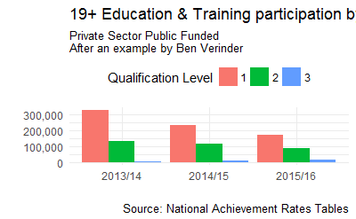

```r
et2015_6 %>% filter(`Institution Type` == "Private Sector Public Funded", Age == "19+", `Qualification Level` %in% c(1,2,3)) %>%  select(`Hybrid End Year`, `Qualification Level`, `Overall Cohort`) %>% type_convert()-> et2015_6_short
et2014_5 %>% filter(`Institution Type` == "Private Sector Public Funded", Age == "19+", `Qualification Level` %in% c(1,2,3)) %>%  select(`Hybrid End Year`, `Qualification Level`, `Overall Cohort`) %>% type_convert()-> et2014_5_short
et2013_4 %>% filter(Institution_Type == "Private Sector Public Funded", Age == "19+", Qualification_Level %in% c(1,2,3)) %>%  select(Hybrid_End_Year, Qualification_Level, `Overall_Leavers`) %>% type_convert() -> et2013_4_short
et2013_6_short <- bind_rows(et2014_5_short, et2015_6_short)
ggplot(et2013_6_short, aes(x=`Hybrid End Year`, y=`Overall Cohort`, fill=as.factor(`Qualification Level`))) + geom_bar(position="dodge", stat="identity") + scale_y_continuous(labels=scales::comma_format()) + theme_minimal() + labs(x="", y="", title="19+ Education & Training participation by level 2013-2016", subtitle="Private Sector Public Funded \nAfter an example by Ben Verinder", caption = "Source: National Achievement Rates Tables") + guides(fill=guide_legend(direction="horizontal", title="Qualification Level")) + theme(legend.position="top")
```

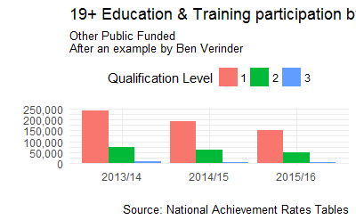

```r
et2015_6 %>% filter(`Institution Type` == "Other Public Funded", Age == "19+", `Qualification Level` %in% c(1,2,3)) %>%  select(`Hybrid End Year`, `Qualification Level`, `Overall Cohort`) %>% type_convert()-> et2015_6_short
et2014_5 %>% filter(`Institution Type` == "Other Public Funded", Age == "19+", `Qualification Level` %in% c(1,2,3)) %>%  select(`Hybrid End Year`, `Qualification Level`, `Overall Cohort`) %>% type_convert()-> et2014_5_short
et2013_4 %>% filter(Institution_Type == "Other Public Funded", Age == "19+", Qualification_Level %in% c(1,2,3)) %>%  select(Hybrid_End_Year, Qualification_Level, `Overall_Leavers`) %>% type_convert() -> et2013_4_short
et2013_6_short <- bind_rows(et2014_5_short, et2015_6_short)
ggplot(et2013_6_short, aes(x=`Hybrid End Year`, y=`Overall Cohort`, fill=as.factor(`Qualification Level`))) + geom_bar(position="dodge", stat="identity") + scale_y_continuous(labels=scales::comma_format()) + theme_minimal() + labs(x="", y="", title="19+ Education & Training participation by level 2013-2016", subtitle="Other Public Funded \nAfter an example by Ben Verinder", caption = "Source: National Achievement Rates Tables") + guides(fill=guide_legend(direction="horizontal", title="Qualification Level")) + theme(legend.position="top")
```

I’ve ignored Schools and sixth form colleges, as their 19+ provision is minimal.

However, it appears that Education and Training excludes Apprenticeships (even when these are delivered by Colleges or other E&T institutions) as well as workplace learning and community learning, all of which are within the Further Education SFR populations. There are NARTS for Apprenticeships, so we can add up Apprenticeship and E&T populations, but not for Workplace Learning or Community Learning.

It’s likely that part of the story is 19+ provision increasingly being classified as apprenticeship - we know about this for Workplace Learning, where Apprenticeships replaced Train to Gain, leaving very little.

## Apprenticeships

The Headline Apprenticeships file for 2014-5 includes data for 2012-3, 2013-4 and 2014-5. Which means I just have to load two files (the 2014-5 and the 2015-6) to get a 4-year time series.

For Apprenticeships, the age-groups are different, with the 19+ group in E&T split out into 19-23 and 24+, and there are (obviously) no figures for Level 1. We have Level 2, 3 and 4+ aka Intermediate, Advanced, Higher.

```r
app2012_5 <- read_csv("./NART201_201415_NationalAchievementRateTables_Apprenticeship_Overall_Headline/NART201_201415_NationalAchievementRateTables_Apprenticeship_Overall_Headline.csv", na="-")
app2015_6 <- read_csv("./201516_App_NARTs_Overall/NART201_201516_App_Overall_Headline.csv", na="-")
```

```r
app2012_6 %>%
  filter(Age %in% c("19-23", "24+"), `Apprenticeship Level` %in% c(2,3)) %>%       select(`Institution Type`,`Hybrid End Year`, `Apprenticeship Level`, `Overall Cohort`) %>%
  group_by(`Institution Type`, `Hybrid End Year`) %>%
  summarise(Participation = sum(`Overall Cohort`)) -> app2012_6_short
```

## Participation rates

Let’s find some decent denominators for participation v need. Using Annual Population Survey data on NOMIS, I can find numbers for the population *with* different qualification levels in various age-groups. Therefore, I can find the numbers in those age-groups *without* those qualifications. I can add up the age-groups to give me population numbers 20-64 with and without specific qualification levels.

I’ll do this for England, just so that the populations are comparable to the English DfE/BIS stats.

```r
population_bases <- read_csv("https://www.nomisweb.co.uk/api/v01/dataset/NM_17_1.data.csv?geography=2092957699&date=latestMINUS49,latestMINUS45,latestMINUS41,latestMINUS37,latestMINUS33,latestMINUS29,latestMINUS25,latestMINUS21,latestMINUS17,latestMINUS13,latestMINUS9,latestMINUS5,latestMINUS1&cell=403899649...403899655,403899905...403899911,403900161...403900167,403900417...403900423,403900673...403900679&measures=20100,20701&signature=NPK-5485242523029816119d0d:0x5630b7fb05697aab74c2b958d53bd040db10a87a")
```